# How to compare models with survxai

Alicja Gosiewska, Aleksandra Grudziaz

2018-08-15

# 1 Introduction

Package *survxai* contains functions for creating a unified representation of a survival models. Such representations can be further processed by various survival explainers. Tools implemented in *survxai* help to understand how input variables are used in the model and what impact do they have on final model prediction.

The analyses carried out using this package can be divided into two parts: local analyses of new observations and global analyses showing the structures of survival models. In this vignette we present both, global and local explanations.

Methods and functions in *survxai* package are based on [*DALEX* package](https://github.com/pbiecek/DALEX).

# 2 Use case - data

## 2.1 Data set

We use the data from the Mayo Clinic trial in primary biliary cirrhosis (PBC) of the liver conducted between 1974 and 1984. A total of 424 PBC patients, referred to Mayo Clinic during that ten-year interval, met eligibility criteria for the randomized placebo controlled trial of the drug D-penicillamine. First 312 cases in the data set participated in the randomized trial and contain largely complete data. The `pbc` data is included in the [*randomForestSRC* package](https://cran.r-project.org/web/packages/randomForestSRC/index.html).

We base models on three variables from `pbc` data set. They are `stage`, `sex`, and `bili`. For this purpouse we create a new data set `pbc_smaller`. We also change `days` for `years`.

```r
data(pbc, package = "randomForestSRC")
pbc <- pbc[complete.cases(pbc),]
pbc_smaller <- pbc[,c("days", "status","sex", "bili", "stage")]
pbc_smaller$years <- pbc$days/365
pbc_smaller <- pbc_smaller[,-1]
head(pbc_smaller)
```

```
##   status sex bili stage     years
## 1      1   1 14.5     4  1.095890
## 2      0   1  1.1     3 12.328767
## 3      1   0  1.4     4  2.772603
## 4      1   1  1.8     4  5.273973
## 5      0   1  3.4     3  4.120548
## 7      0   1  1.0     3  5.019178
```

We also convert variables `sex` and `stage` to factors.

```r
pbc_smaller$sex <- as.factor(pbc_smaller$sex)
pbc_smaller$stage <- as.factor(pbc_smaller$stage)
```

We divide our data set into train and test sets.

```r
smp_size <- floor(0.5 * nrow(pbc_smaller))
set.seed(123)
train_ind <- sample(seq_len(nrow(pbc_smaller)), size = smp_size)

train <- pbc_smaller[train_ind, ]
test <- pbc_smaller[-train_ind, ]
```

## 2.2 Models

In this section, we create 3 models: Cox Proportional Hazards Model, Random Forests for Survival, and Parametric Survival Regression Model.

### 2.2.1 Cox Proportional Hazards Model

```r
library(rms)

cph_model <- cph(Surv(years, status)~., data = train, surv = TRUE, x = TRUE, y=TRUE)
```

### 2.2.2 Random Forests for Survival

```r
library(randomForestSRC)
set.seed(1994)
rf_model <- rfsrc(Surv(years, status)~., data = train)
```

### 2.2.3 Parametric Survival Regression Model

```r
library(survival)
reg_model <- survreg(Surv(years, status)~., data = train, x = TRUE)
```

# 3 Explanation

First, we have to create survival explainers - objects that wrap-up the black-box model with meta-data. Explainers unify model interfacing.

Some models require custom predict function. Examples are in [Custom predict function for survival models vignette](https://mi2datalab.github.io/survxai/articles/Custom_predict_for_survival_models.html).

Predict functions for `cph` and `rfsrc` objects are implemented.

```r
library(survxai)

surve_cph <- explain(model = cph_model,
                     data = test[,-c(1,5)],
                     y = Surv(test$years, test$status))

print(surve_cph)
```

```
## Model label:  coxph
## Model class:  cph,rms,coxph
## Data head  :
##   sex bili stage
## 2   1  1.1     3
## 3   0  1.4     4
```

```r
surve_rf <- explain(model = rf_model,
                     label = "random forest",
                     data = test[,-c(1,5)],
                     y = Surv(test$years, test$status))

print(surve_rf)
```

```
## Model label:  random forest
## Model class:  rfsrc,grow,surv
## Data head  :
##   sex bili stage
## 2   1  1.1     3
## 3   0  1.4     4
```

For model created by `survreg()` function we have to add specific custom predict function. We add this function to explainer by `predict_function` parameter.

```r
library(CFC)

custom_predict <- function(model, newdata, times){
  times <- sort(times)
  vars <- all.vars(model$call[[2]][[2]])
  n_vars <- which(colnames(newdata) %in% vars)
  if(length(n_vars)>0){
    newdata <- newdata[,-c(n_vars)]
  }
  model$x <- model.matrix(~., newdata)
  res <- matrix(ncol = length(times), nrow = nrow(newdata))
  for(i in 1:nrow(newdata)) {
    res[i,] <- cfc.survreg.survprob(t = times, args = model, n = i)
  }
  return(res)
}

surve_reg <- explain(model = reg_model,
                     data = test[,-c(1,5)],
                     y = Surv(test$years, test$status),
                     predict_function = custom_predict)
print(surve_reg)
```

```
## Model label:  survreg
## Model class:  survreg
## Data head  :
##   sex bili stage
## 2   1  1.1     3
## 3   0  1.4     4
```

## 3.1 Global explanations

At the beginning, we are dealing with global explanations. We focus on explanations of the global and conditional model structure.

### 3.1.1 Model performance

Currently, in the *survxai* package is implemented only the `BS` type of model performance. In this metod for each time point we compute the prediction error for model. We compute `model_performance` explainers for all three models created above.

```r
mp_cph <- model_performance(surve_cph)
mp_rf <- model_performance(surve_rf)
mp_reg <- model_performance(surve_reg)
```

For each explainer we can print values using generic `print()` function.

```r
print(mp_cph)
```

```
## Model performance for Brier Score method.
##    time prediction error
## 1     0             ~ 0%
## 2     1           ~ 6.6%
## 3     2           ~ 7.3%
## 4     3         ~ 10.95%
## 5     4         ~ 11.43%
## 6     5         ~ 13.06%
## 7     6         ~ 13.05%
## 8     7         ~ 13.99%
## 9     8         ~ 15.93%
## 10    9         ~ 20.18%
## 11   10         ~ 17.21%
## 12   11         ~ 21.91%
## 13   12         ~ 24.89%
```

We plot all three models using generic `plot()` function.

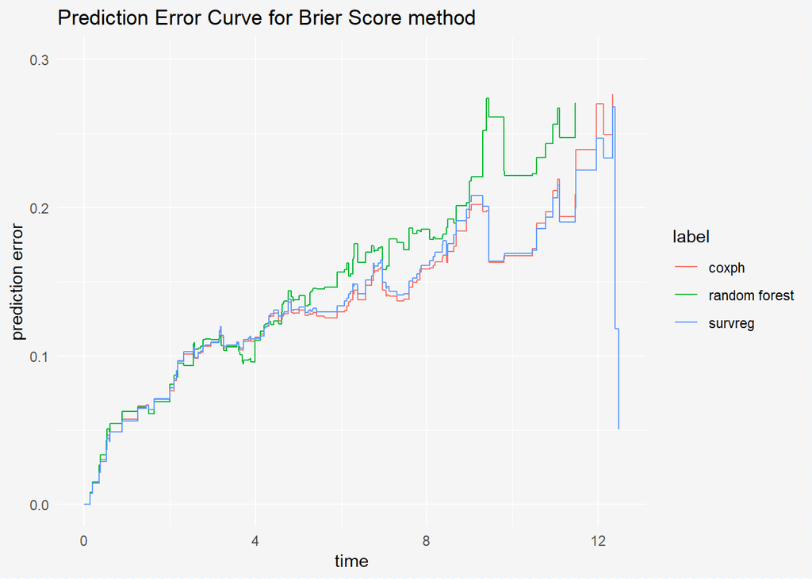

```r
plot(mp_cph, mp_rf, mp_reg) + ylim(c(0,0.30))
```

### 3.1.2 Variable response

Variable response explainers are designed to better understand the relation between a variable and a model output. We compute `variable_response` explainers for all three models created above.

#### 3.1.2.1 Factor variable

First, we compute explainers for the factor variable `sex`.

```r
vr_cph_sex <- variable_response(surve_cph, "sex")
vr_rf_sex <- variable_response(surve_rf, "sex")
vr_reg_sex <- variable_response(surve_reg, "sex")
```

For each explainer we can print values using generic `print()` function.

```r
print(vr_cph_sex)
```

```
##           x         y value type label var
## 1 0.1397260 0.9922858     1  pdp coxph sex
## 2 0.1945205 0.9922858     1  pdp coxph sex
## 3 0.3589041 0.9762765     1  pdp coxph sex
## 4 0.3835616 0.9762765     1  pdp coxph sex
## 5 0.5232877 0.9613915     1  pdp coxph sex
## 6 0.5424658 0.9613915     1  pdp coxph sex
```

We visualize explainers on one plot.

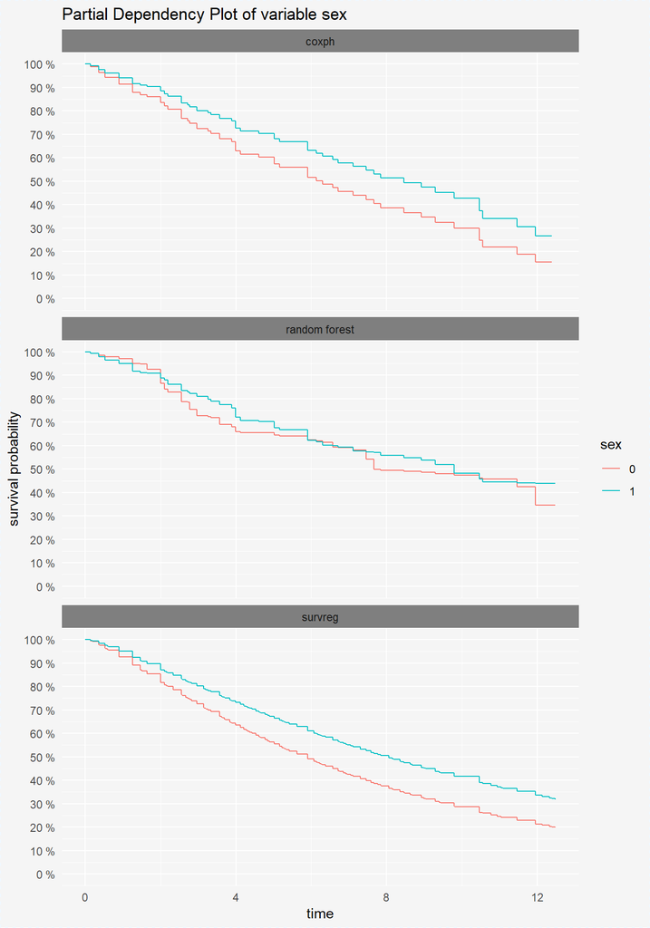

```r
plot(vr_cph_sex, vr_rf_sex, vr_reg_sex)
```

In `survival_variable_response` plots we can also compare models in division into all variable levels using parameter `split = "variable"`.

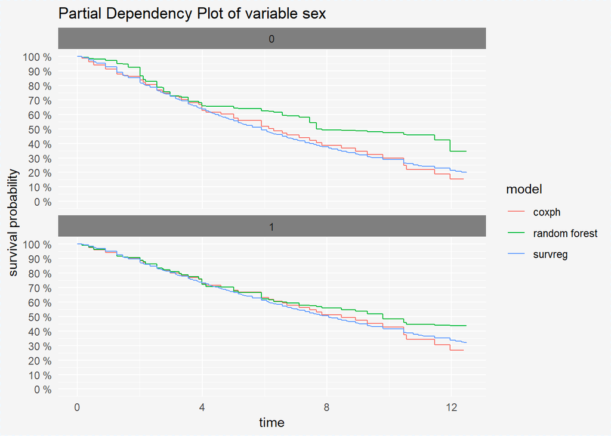

```r
plot(vr_cph_sex, vr_rf_sex, vr_reg_sex, split = "variable")
```

#### 3.1.2.2 Continuous variable

```r
vr_cph_bili <- variable_response(surve_cph, "bili")
vr_rf_bili <- variable_response(surve_rf, "bili")
vr_reg_bili <- variable_response(surve_reg, "bili")
```

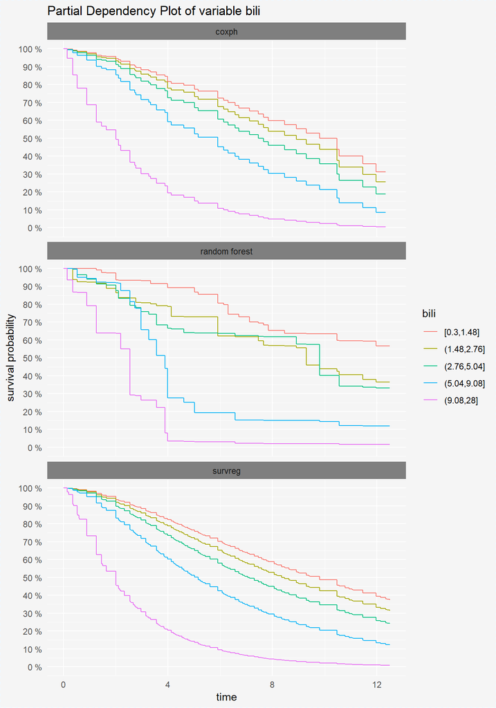

```r
plot(vr_cph_bili, vr_rf_bili, vr_reg_bili)
```

As mentioned above we can split our comparison by each variable level.

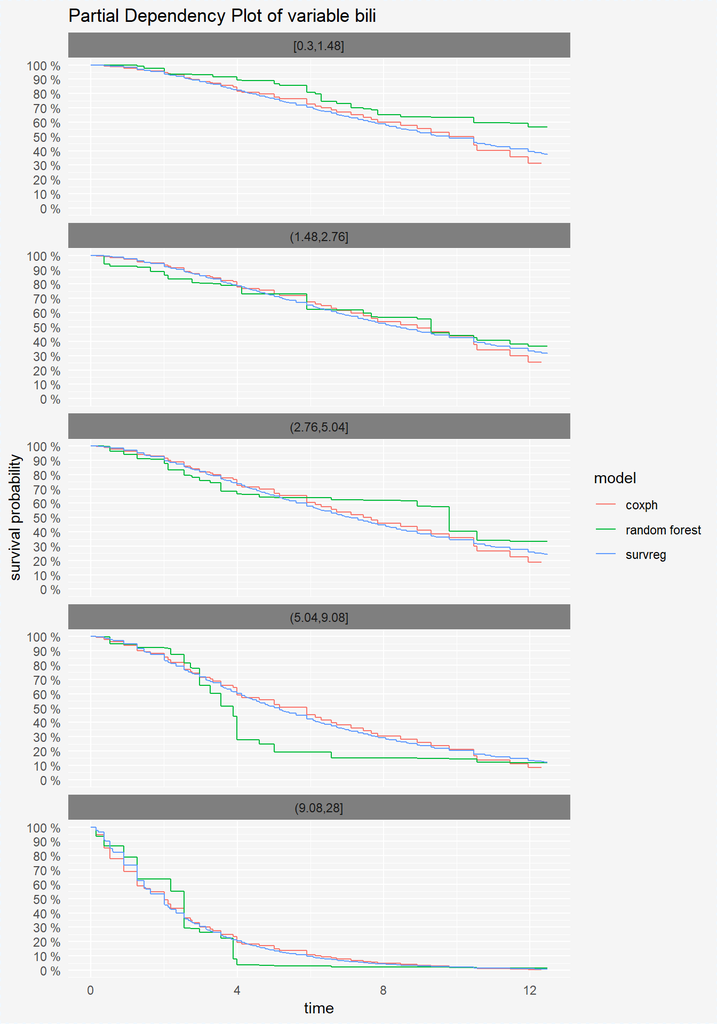

```r
plot(vr_cph_bili, vr_rf_bili, vr_reg_bili, split = "variable")
```

## 3.2 Local explanations

The next aspects of survival model analysis are local explanations - the explanations for one, new observation.

```r
single_observation <- test[1,-c(1,5)]
single_observation
```

```
##   sex bili stage
## 2   1  1.1     3
```

### 3.2.1 Ceteris paribus

Ceteris Paribus Plots for survival models are survival curves around one observation. Each curve represent observation with different value of chosen variable. For factor variables curves covers all possible values, for numeric variables values are divided into quantiles.

```r
cp_cph <- ceteris_paribus(surve_cph, single_observation)
cp_rf <- ceteris_paribus(surve_rf, single_observation)
cp_reg <- ceteris_paribus(surve_reg, single_observation)
```

For each ceteris paribus explainer we can print values using generic `print()` function.

```r
print(cp_cph)
```

```
##       y_hat new_x vname x_quant quant relative_quant label      time
## 1 0.9978522     0   sex       0     0              0 coxph 0.1397260
## 2 0.9978522     0   sex       0     0              0 coxph 0.1945205
## 3 0.9927118     0   sex       0     0              0 coxph 0.3589041
## 4 0.9927118     0   sex       0     0              0 coxph 0.3835616
## 5 0.9870411     0   sex       0     0              0 coxph 0.5232877
## 6 0.9870411     0   sex       0     0              0 coxph 0.5424658
##    class
## 1 factor
## 2 factor
## 3 factor
## 4 factor
## 5 factor
## 6 factor
```

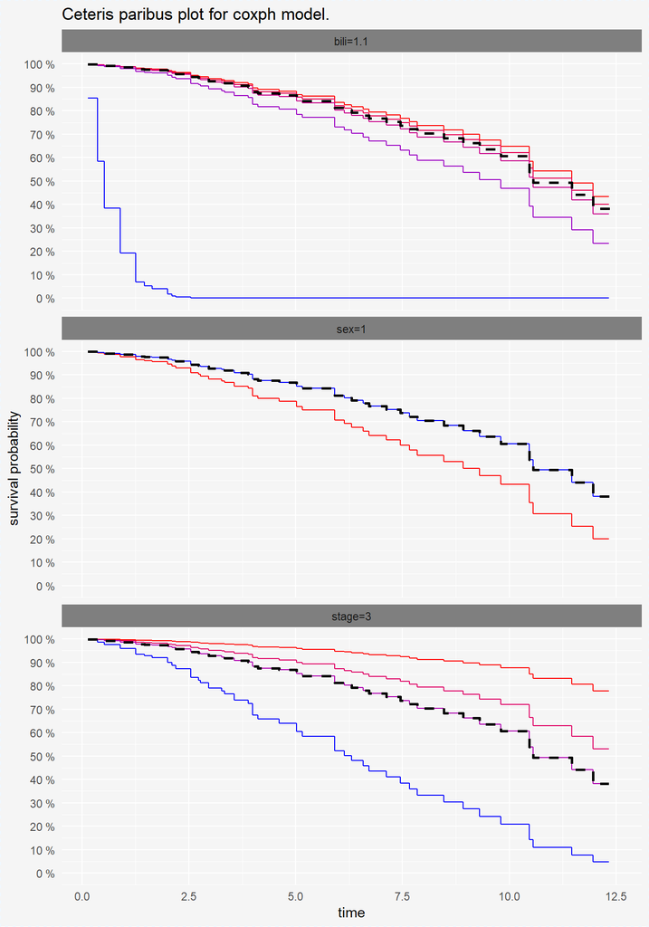

```r
plot(cp_cph, scale_type = "gradient", scale_col = c("red", "blue"))
```

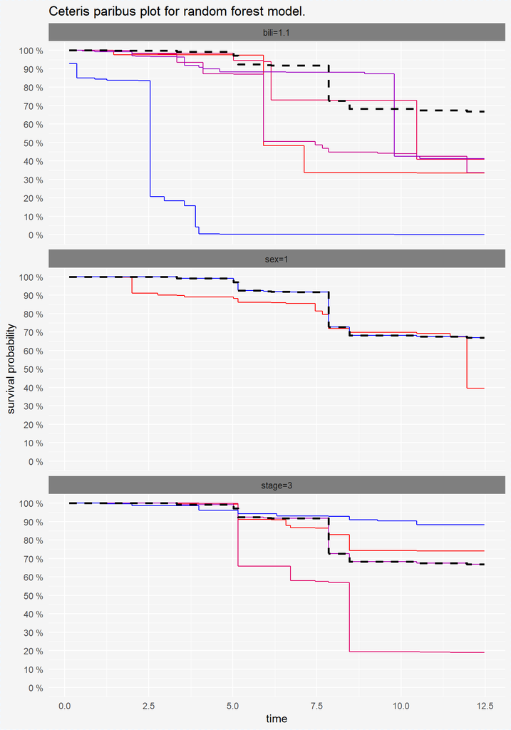

```r
plot(cp_rf, scale_type = "gradient", scale_col = c("red", "blue"))
```

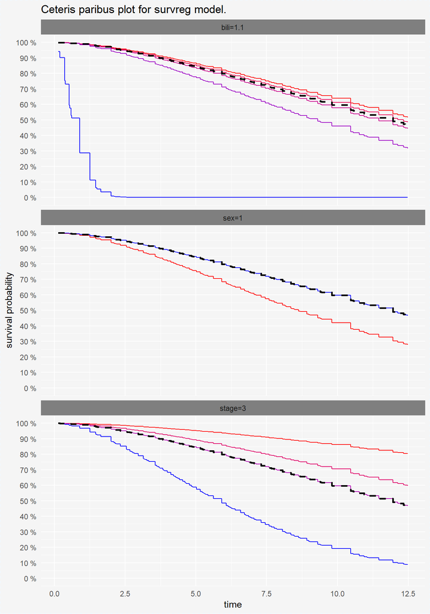

```r
plot(cp_reg, scale_type = "gradient", scale_col = c("red", "blue"))
```

On the plots above we see that for variables `bili` and `sex` `coxph` and `survreg` model have simmilar performance, but `randomForest` model has different predictions of survival probability.

### 3.2.2 Prediction breakdown

Break Down Plots for survival models compare, by default, differences in predictions for median of time. We can change the time of computing the contributions for each variable using `time` parameter.

```r
broken_prediction_cph <- prediction_breakdown(surve_cph, single_observation)
broken_prediction_rf <- prediction_breakdown(surve_rf, single_observation)
broken_prediction_reg <- prediction_breakdown(surve_reg, single_observation)
```

For each prediction breakdown explainer we can print values using generic `print()` function.

```r
print(broken_prediction_cph)
```

```
##       contribution
## bili       10.103%
## stage       7.714%
## sex         1.069%
```

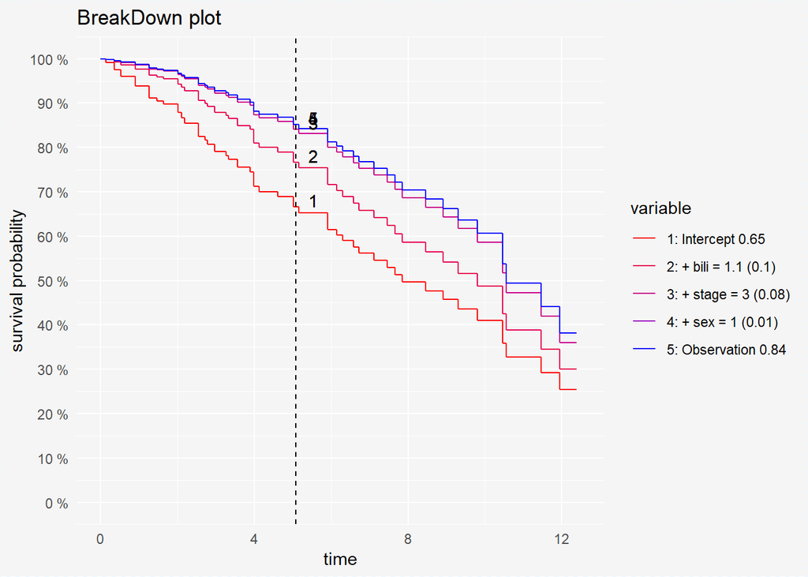

```r
plot(broken_prediction_cph, scale_col = c("red", "blue"), lines_type = 2)
```

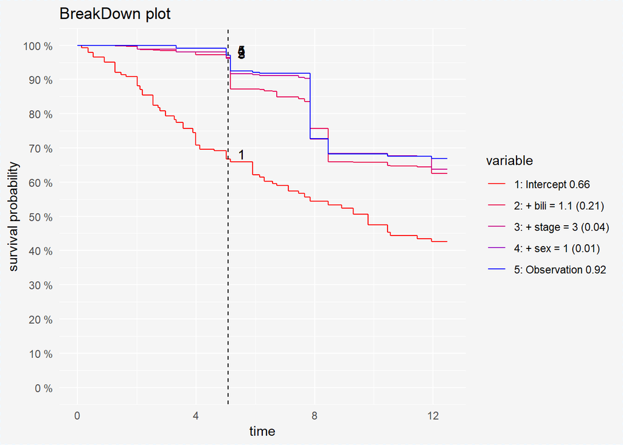

```r
plot(broken_prediction_rf, scale_col = c("red", "blue"), lines_type = 2)
```

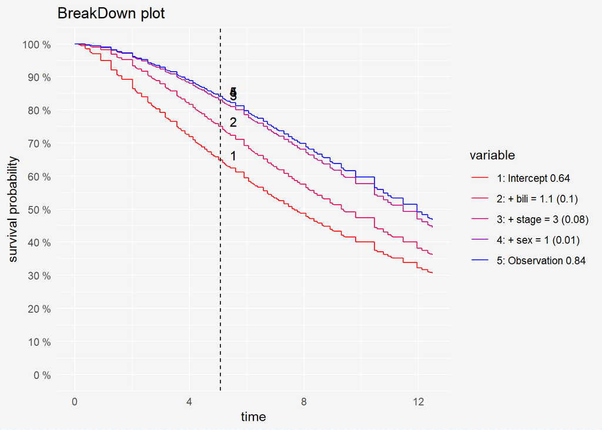

```r
plot(broken_prediction_reg, scale_col = c("red", "blue"), lines_type = 2)
```

This plots helps to understand the factors that drive survival probability for a single observation.

We can also compute the variables contribution for chosen survival probability value.

```r
broken_prediction_cph <- prediction_breakdown(surve_cph, single_observation, prob = 0.8)
broken_prediction_rf <- prediction_breakdown(surve_rf, single_observation, prob = 0.8)
broken_prediction_reg <- prediction_breakdown(surve_reg, single_observation, prob = 0.8)
```

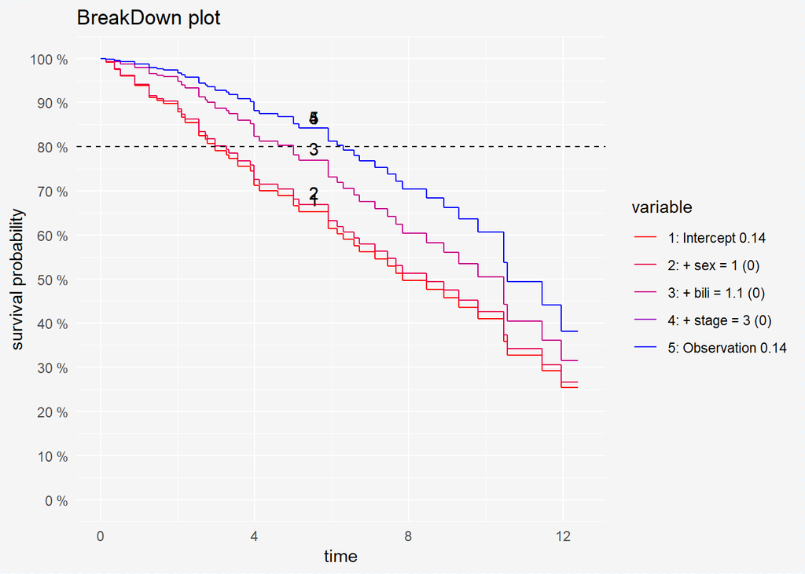

```r
plot(broken_prediction_cph, scale_col = c("red", "blue"), lines_type = 2)
```

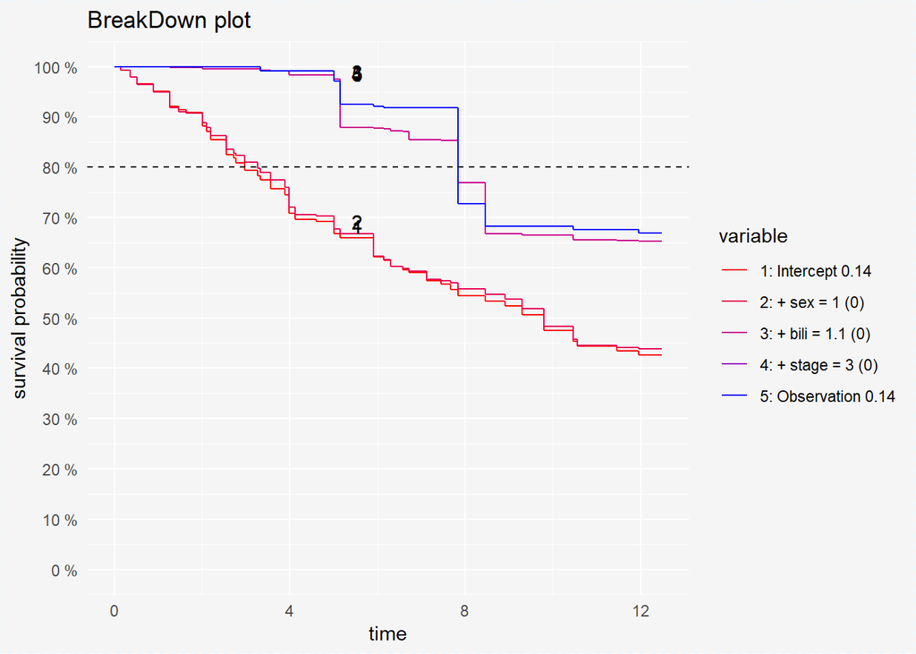

```r
plot(broken_prediction_rf, scale_col = c("red", "blue"), lines_type = 2)
```

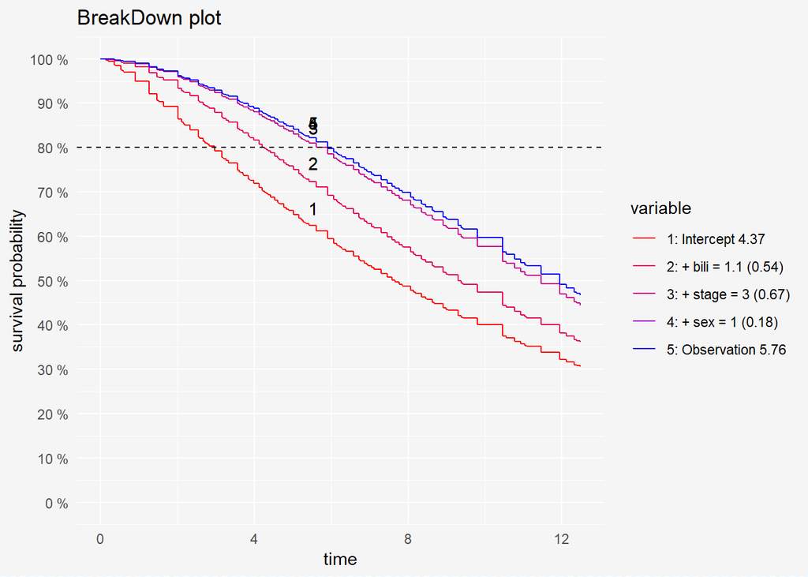

```r
plot(broken_prediction_reg, scale_col = c("red", "blue"), lines_type = 2)
```

We can compare this models on one plot.

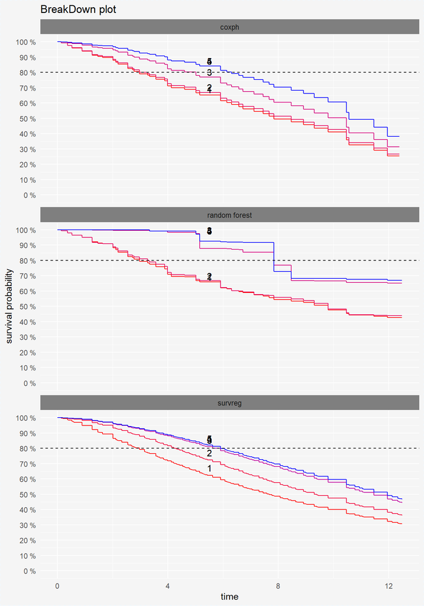

```r
plot(broken_prediction_cph, broken_prediction_rf, broken_prediction_reg, scale_col = c("red", "blue"), lines_type = 2)
```

For the transparency of the charts we recommend drawning them separately.